# Task 2.2 Exploratory Data Analysis

- Batch - B
- Group Number - 5
- Group Member - Yashwanth K

### Missing values identification and treatment

```python
import pandas as pd
import numpy as np
import matplotlib.pyplot as plt
%matplotlib inline
import seaborn as sns
import warnings
warnings.simplefilter(action = 'ignore')
```

```python
data = pd.read_csv("Store.csv")
data.head()
```

|  | Row ID | Order ID | Order Date | Ship Date | Ship Mode | Customer ID | Customer Name | Segment | Country | City_Code | State_Code | Postal Code | Product ID | Category | Sub-Category | Product Name | Sales | Quantity | Discount | Profit |
| --- | --- | --- | --- | --- | --- | --- | --- | --- | --- | --- | --- | --- | --- | --- | --- | --- | --- | --- | --- | --- |
| 0 | 7981 | CA-2011-103800 | 1/4/2011 | 1/8/2011 | Standard Class | DP-13000 | Darren Powers | Consumer | United States | C522 | S42 | 77095 | OFF-PA-10000174 | Office Supplies | Paper | Message Book, Wirebound, Four 5 1/2" X 4" Form... | 16.448 | 2 | 0.2 | 5.5512 |
| 1 | 740 | CA-2011-112326 | 1/5/2011 | 1/9/2011 | Standard Class | PO-19195 | Phillina Ober | Home Office | United States | C212 | S12 | 60540 | OFF-LA-10003223 | Office Supplies | Labels | Avery 508 | 11.784 | 3 | 0.2 | 4.2717 |
| 2 | 741 | CA-2011-112326 | 1/5/2011 | 1/9/2011 | Standard Class | PO-19195 | Phillina Ober | Home Office | United States | C212 | S12 | 60540 | OFF-ST-10002743 | Office Supplies | Storage | SAFCO Boltless Steel Shelving | 272.736 | 3 | 0.2 | -64.7748 |
| 3 | 742 | CA-2011-112326 | 1/5/2011 | 1/9/2011 | Standard Class | PO-19195 | Phillina Ober | Home Office | United States | C212 | S12 | 60540 | OFF-BI-10004094 | Office Supplies | Binders | GBC Standard Plastic Binding Systems Combs | 3.540 | 2 | 0.8 | -5.4870 |
| 4 | 1760 | CA-2011-141817 | 1/6/2011 | 1/13/2011 | Standard Class | MB-18085 | Mick Brown | Consumer | United States | C464 | S37 | 19143 | OFF-AR-10003478 | Office Supplies | Art | Avery Hi-Liter EverBold Pen Style Fluorescent ... | 19.536 | 3 | 0.2 | 4.8840 |

```python
data.isnull().sum()
```

```
Row ID            0
Order ID          0
Order Date        0
Ship Date         0
Ship Mode        22
Customer ID       0
Customer Name     0
Segment           9
Country           6
City_Code         0
State_Code        0
Postal Code       0
Product ID        0
Category          0
Sub-Category      0
Product Name      0
Sales             0
Quantity          0
Discount          0
Profit            0
dtype: int64
```

```python
import statistics
```

```python
data['Ship Mode'].value_counts().idxmax()
```

```
'Standard Class'
```

Since there are only 22 values missing out of 9994 we can just make use of idxmax() function to get the value that is most frequently occuring in the dataset and use that value to fill the null values.

```python
data['Ship Mode'] = data['Ship Mode'].fillna('Standard Class')
```

```python
data.isnull().sum()
```

```
Row ID           0
Order ID         0
Order Date       0
Ship Date        0
Ship Mode        0
Customer ID      0
Customer Name    0
Segment          9
Country          6
City_Code        0
State_Code       0
Postal Code      0
Product ID       0
Category         0
Sub-Category     0
Product Name     0
Sales            0
Quantity         0
Discount         0
Profit           0
dtype: int64
```

```python
data.Country.unique()
```

```
array(['United States', nan], dtype=object)
```

```python
data['Country'] = data['Country'].fillna('United States')
```

```python
data.isnull().sum()
```

```
Row ID           0
Order ID         0
Order Date       0
Ship Date        0
Ship Mode        0
Customer ID      0
Customer Name    0
Segment          9
Country          0
City_Code        0
State_Code       0
Postal Code      0
Product ID       0
Category         0
Sub-Category     0
Product Name     0
Sales            0
Quantity         0
Discount         0
Profit           0
dtype: int64
```

Since there are very few rows where we have null values for segment we can just delete them as filling them with values with mean median or mode would not make sense

```python
data = data.dropna()
```

```python
data.isnull().sum()
```

```
Row ID           0
Order ID         0
Order Date       0
Ship Date        0
Ship Mode        0
Customer ID      0
Customer Name    0
Segment          0
Country          0
City_Code        0
State_Code       0
Postal Code      0
Product ID       0
Category         0
Sub-Category     0
Product Name     0
Sales            0
Quantity         0
Discount         0
Profit           0
dtype: int64
```

```python
data.shape[0]
```

```
9985
```

So we finally have 9985 rows in our dataset that we can work with.

```python
data.describe()
```

|  | Row ID | Postal Code | Sales | Quantity | Discount | Profit |
| --- | --- | --- | --- | --- | --- | --- |
| count | 9985.000000 | 9985.00000 | 9985.000000 | 9985.000000 | 9985.000000 | 9985.000000 |
| mean | 4993.896545 | 55182.79359 | 229.636100 | 3.789685 | 0.156183 | 28.587722 |
| std | 2883.894709 | 32060.89504 | 622.927104 | 2.225074 | 0.206477 | 234.183523 |
| min | 1.000000 | 1040.00000 | 0.444000 | 1.000000 | 0.000000 | -6599.978000 |
| 25% | 2497.000000 | 23223.00000 | 17.280000 | 2.000000 | 0.000000 | 1.731000 |
| 50% | 4993.000000 | 56301.00000 | 54.500000 | 3.000000 | 0.200000 | 8.671500 |
| 75% | 7489.000000 | 90008.00000 | 209.940000 | 5.000000 | 0.200000 | 29.364000 |
| max | 9994.000000 | 99301.00000 | 22638.480000 | 14.000000 | 0.800000 | 8399.976000 |

we can see that order date and ship date are of the type object

we need to convert them into datetime for us to get any inferences from those rows

```python
data.columns = data.columns.str.replace(' ','_')
```

```python
data['Ship_Date'] = data['Ship_Date'].str.replace('-','/')
data['Ship_Date']
data['Order_Date'] = data['Order_Date'].str.replace('-','/')
data['Order_Date']
```

```
0         1/4/2011
1         1/5/2011
2         1/5/2011
3         1/5/2011
4         1/6/2011
           ...
9989    12/31/2014
9990    12/31/2014
9991    12/31/2014
9992    12/31/2014
9993    12/31/2014
Name: Order_Date, Length: 9985, dtype: object
```

```python
data['Order_Date'] = pd.to_datetime(data['Order_Date'])
data['Ship_Date'] = pd.to_datetime(data['Ship_Date'])
data.info()
```

```
<class 'pandas.core.frame.DataFrame'>
Int64Index: 9985 entries, 0 to 9993
Data columns (total 20 columns):
 #   Column         Non-Null Count  Dtype
---  ------         --------------  -----
 0   Row_ID         9985 non-null   int64
 1   Order_ID       9985 non-null   object
 2   Order_Date     9985 non-null   datetime64[ns]
 3   Ship_Date      9985 non-null   datetime64[ns]
 4   Ship_Mode      9985 non-null   object
 5   Customer_ID    9985 non-null   object
 6   Customer_Name  9985 non-null   object
 7   Segment        9985 non-null   object
 8   Country        9985 non-null   object
 9   City_Code      9985 non-null   object
 10  State_Code     9985 non-null   object
 11  Postal_Code    9985 non-null   int64
 12  Product_ID     9985 non-null   object
 13  Category       9985 non-null   object
 14  Sub-Category   9985 non-null   object
 15  Product_Name   9985 non-null   object
 16  Sales          9985 non-null   float64
 17  Quantity       9985 non-null   int64
 18  Discount       9985 non-null   float64
 19  Profit         9985 non-null   float64
dtypes: datetime64[ns](2), float64(3), int64(3), object(12)
memory usage: 1.6+ MB
```

```python
data['Order_Year']=data['Order_Date'].dt.year
data['WeekDay']=data['Order_Date'].dt.day_name()
```

```python
data.head()
```

|  | Row_ID | Order_ID | Order_Date | Ship_Date | Ship_Mode | Customer_ID | Customer_Name | Segment | Country | City_Code | ... | Product_ID | Category | Sub-Category | Product_Name | Sales | Quantity | Discount | Profit | Order_Year | WeekDay |
| --- | --- | --- | --- | --- | --- | --- | --- | --- | --- | --- | --- | --- | --- | --- | --- | --- | --- | --- | --- | --- | --- |
| 0 | 7981 | CA-2011-103800 | 2011-01-04 | 2011-01-08 | Standard Class | DP-13000 | Darren Powers | Consumer | United States | C522 | ... | OFF-PA-10000174 | Office Supplies | Paper | Message Book, Wirebound, Four 5 1/2" X 4" Form... | 16.448 | 2 | 0.2 | 5.5512 | 2011 | Tuesday |
| 1 | 740 | CA-2011-112326 | 2011-01-05 | 2011-01-09 | Standard Class | PO-19195 | Phillina Ober | Home Office | United States | C212 | ... | OFF-LA-10003223 | Office Supplies | Labels | Avery 508 | 11.784 | 3 | 0.2 | 4.2717 | 2011 | Wednesday |
| 2 | 741 | CA-2011-112326 | 2011-01-05 | 2011-01-09 | Standard Class | PO-19195 | Phillina Ober | Home Office | United States | C212 | ... | OFF-ST-10002743 | Office Supplies | Storage | SAFCO Boltless Steel Shelving | 272.736 | 3 | 0.2 | -64.7748 | 2011 | Wednesday |
| 3 | 742 | CA-2011-112326 | 2011-01-05 | 2011-01-09 | Standard Class | PO-19195 | Phillina Ober | Home Office | United States | C212 | ... | OFF-BI-10004094 | Office Supplies | Binders | GBC Standard Plastic Binding Systems Combs | 3.540 | 2 | 0.8 | -5.4870 | 2011 | Wednesday |
| 4 | 1760 | CA-2011-141817 | 2011-01-06 | 2011-01-13 | Standard Class | MB-18085 | Mick Brown | Consumer | United States | C464 | ... | OFF-AR-10003478 | Office Supplies | Art | Avery Hi-Liter EverBold Pen Style Fluorescent ... | 19.536 | 3 | 0.2 | 4.8840 | 2011 | Thursday |

5 rows × 22 columns

## Univariate

```python
df = pd.read_csv("store-data.csv")
```

```python
df
```

|  | Row_ID | Order_ID | Order_Date | Ship_Date | Ship_Mode | Customer_ID | Customer_Name | Segment | Country | City_Code | ... | Category | Sub-Category | Product_Name | Sales | Quantity | Discount | Profit | Order_Year | Duration | WeekDay |
| --- | --- | --- | --- | --- | --- | --- | --- | --- | --- | --- | --- | --- | --- | --- | --- | --- | --- | --- | --- | --- | --- |
| 0 | 7981 | CA-2011-103800 | 4/1/2011 | 8-1-2011 | Standard Class | DP-13000 | Darren Powers | Consumer | United States | C522 | ... | Office Supplies | Paper | Message Book, Wirebound, Four 5 1/2" X 4" Form... | 16.448 | 2 | 0.2 | 5.5512 | 2011 | 4 days | Tuesday |
| 1 | 740 | CA-2011-112326 | 5/1/2011 | 9-1-2011 | Standard Class | PO-19195 | Phillina Ober | Home Office | United States | C212 | ... | Office Supplies | Labels | Avery 508 | 11.784 | 3 | 0.2 | 4.2717 | 2011 | 4 days | Wednesday |
| 2 | 741 | CA-2011-112326 | 5/1/2011 | 9-1-2011 | Standard Class | PO-19195 | Phillina Ober | Home Office | United States | C212 | ... | Office Supplies | Storage | SAFCO Boltless Steel Shelving | 272.736 | 3 | 0.2 | -64.7748 | 2011 | 4 days | Wednesday |
| 3 | 742 | CA-2011-112326 | 5/1/2011 | 9-1-2011 | Standard Class | PO-19195 | Phillina Ober | Home Office | United States | C212 | ... | Office Supplies | Binders | GBC Standard Plastic Binding Systems Combs | 3.540 | 2 | 0.8 | -5.4870 | 2011 | 4 days | Wednesday |
| 4 | 1760 | CA-2011-141817 | 6/1/2011 | 13-1-2011 | Standard Class | MB-18085 | Mick Brown | Consumer | United States | C464 | ... | Office Supplies | Art | Avery Hi-Liter EverBold Pen Style Fluorescent ... | 19.536 | 3 | 0.2 | 4.8840 | 2011 | 7 days | Thursday |
| ... | ... | ... | ... | ... | ... | ... | ... | ... | ... | ... | ... | ... | ... | ... | ... | ... | ... | ... | ... | ... | ... |
| 9980 | 908 | CA-2014-143259 | 31/12/2014 | 4-1-2015 | Standard Class | PO-18865 | Patrick O'Donnell | Consumer | United States | C390 | ... | Technology | Phones | Gear Head AU3700S Headset | 90.930 | 7 | 0.0 | 2.7279 | 2014 | 4 days | Wednesday |
| 9981 | 909 | CA-2014-143259 | 31/12/2014 | 4-1-2015 | Standard Class | PO-18865 | Patrick O'Donnell | Consumer | United States | C390 | ... | Office Supplies | Binders | Wilson Jones Legal Size Ring Binders | 52.776 | 3 | 0.2 | 19.7910 | 2014 | 4 days | Wednesday |
| 9982 | 1297 | CA-2014-115427 | 31/12/2014 | 4-1-2015 | Standard Class | EB-13975 | Erica Bern | Corporate | United States | C50 | ... | Office Supplies | Binders | Cardinal Slant-D Ring Binder, Heavy Gauge Vinyl | 13.904 | 2 | 0.2 | 4.5188 | 2014 | 4 days | Wednesday |
| 9983 | 1298 | CA-2014-115427 | 31/12/2014 | 4-1-2015 | Standard Class | EB-13975 | Erica Bern | Corporate | United States | C50 | ... | Office Supplies | Binders | GBC Binding covers | 20.720 | 2 | 0.2 | 6.4750 | 2014 | 4 days | Wednesday |
| 9984 | 5092 | CA-2014-156720 | 31/12/2014 | 4-1-2015 | Standard Class | JM-15580 | Jill Matthias | Consumer | United States | C124 | ... | Office Supplies | Fasteners | Bagged Rubber Bands | 3.024 | 3 | 0.2 | -0.6048 | 2014 | 4 days | Wednesday |

9985 rows × 23 columns

```python
data
```

|  | Row_ID | Order_ID | Order_Date | Ship_Date | Ship_Mode | Customer_ID | Customer_Name | Segment | Country | City_Code | ... | Product_ID | Category | Sub-Category | Product_Name | Sales | Quantity | Discount | Profit | Order_Year | WeekDay |
| --- | --- | --- | --- | --- | --- | --- | --- | --- | --- | --- | --- | --- | --- | --- | --- | --- | --- | --- | --- | --- | --- |
| 0 | 7981 | CA-2011-103800 | 2011-01-04 | 2011-01-08 | Standard Class | DP-13000 | Darren Powers | Consumer | United States | C522 | ... | OFF-PA-10000174 | Office Supplies | Paper | Message Book, Wirebound, Four 5 1/2" X 4" Form... | 16.448 | 2 | 0.2 | 5.5512 | 2011 | Tuesday |
| 1 | 740 | CA-2011-112326 | 2011-01-05 | 2011-01-09 | Standard Class | PO-19195 | Phillina Ober | Home Office | United States | C212 | ... | OFF-LA-10003223 | Office Supplies | Labels | Avery 508 | 11.784 | 3 | 0.2 | 4.2717 | 2011 | Wednesday |
| 2 | 741 | CA-2011-112326 | 2011-01-05 | 2011-01-09 | Standard Class | PO-19195 | Phillina Ober | Home Office | United States | C212 | ... | OFF-ST-10002743 | Office Supplies | Storage | SAFCO Boltless Steel Shelving | 272.736 | 3 | 0.2 | -64.7748 | 2011 | Wednesday |
| 3 | 742 | CA-2011-112326 | 2011-01-05 | 2011-01-09 | Standard Class | PO-19195 | Phillina Ober | Home Office | United States | C212 | ... | OFF-BI-10004094 | Office Supplies | Binders | GBC Standard Plastic Binding Systems Combs | 3.540 | 2 | 0.8 | -5.4870 | 2011 | Wednesday |
| 4 | 1760 | CA-2011-141817 | 2011-01-06 | 2011-01-13 | Standard Class | MB-18085 | Mick Brown | Consumer | United States | C464 | ... | OFF-AR-10003478 | Office Supplies | Art | Avery Hi-Liter EverBold Pen Style Fluorescent ... | 19.536 | 3 | 0.2 | 4.8840 | 2011 | Thursday |
| ... | ... | ... | ... | ... | ... | ... | ... | ... | ... | ... | ... | ... | ... | ... | ... | ... | ... | ... | ... | ... | ... |
| 9989 | 908 | CA-2014-143259 | 2014-12-31 | 2015-01-04 | Standard Class | PO-18865 | Patrick O'Donnell | Consumer | United States | C390 | ... | TEC-PH-10004774 | Technology | Phones | Gear Head AU3700S Headset | 90.930 | 7 | 0.0 | 2.7279 | 2014 | Wednesday |
| 9990 | 909 | CA-2014-143259 | 2014-12-31 | 2015-01-04 | Standard Class | PO-18865 | Patrick O'Donnell | Consumer | United States | C390 | ... | OFF-BI-10003684 | Office Supplies | Binders | Wilson Jones Legal Size Ring Binders | 52.776 | 3 | 0.2 | 19.7910 | 2014 | Wednesday |
| 9991 | 1297 | CA-2014-115427 | 2014-12-31 | 2015-01-04 | Standard Class | EB-13975 | Erica Bern | Corporate | United States | C50 | ... | OFF-BI-10002103 | Office Supplies | Binders | Cardinal Slant-D Ring Binder, Heavy Gauge Vinyl | 13.904 | 2 | 0.2 | 4.5188 | 2014 | Wednesday |
| 9992 | 1298 | CA-2014-115427 | 2014-12-31 | 2015-01-04 | Standard Class | EB-13975 | Erica Bern | Corporate | United States | C50 | ... | OFF-BI-10004632 | Office Supplies | Binders | GBC Binding covers | 20.720 | 2 | 0.2 | 6.4750 | 2014 | Wednesday |
| 9993 | 5092 | CA-2014-156720 | 2014-12-31 | 2015-01-04 | Standard Class | JM-15580 | Jill Matthias | Consumer | United States | C124 | ... | OFF-FA-10003472 | Office Supplies | Fasteners | Bagged Rubber Bands | 3.024 | 3 | 0.2 | -0.6048 | 2014 | Wednesday |

9985 rows × 22 columns

```python
df['Order_Date'] = pd.to_datetime(df['Order_Date'],format='%d/%m/%Y')
df.dtypes
```

```
Row_ID                    int64
Order_ID                 object
Order_Date       datetime64[ns]
Ship_Date                object
Ship_Mode                object
Customer_ID              object
Customer_Name            object
Segment                  object
Country                  object
City_Code                object
State_Code               object
Postal_Code               int64
Product_ID               object
Category                 object
Sub-Category             object
Product_Name             object
Sales                   float64
Quantity                  int64
Discount                float64
Profit                  float64
Order_Year                int64
Duration                 object
WeekDay                  object
dtype: object
```

```python
data.drop(columns=['Row_ID','Order_ID','Customer_ID','Customer_Name',"City_Code",'State_Code','Postal_Code','Product_ID'],axis=1,inplace=True)
```

```python
train=data[0:6674]   # Sales data from 2011 to 2013 taken as train
test=data[6675:]     # sales data of 2014 is considered as test data
train.head()
```

|  | Order_Date | Ship_Date | Ship_Mode | Segment | Country | Category | Sub-Category | Product_Name | Sales | Quantity | Discount | Profit | Order_Year | WeekDay |
| --- | --- | --- | --- | --- | --- | --- | --- | --- | --- | --- | --- | --- | --- | --- |
| 0 | 2011-01-04 | 2011-01-08 | Standard Class | Consumer | United States | Office Supplies | Paper | Message Book, Wirebound, Four 5 1/2" X 4" Form... | 16.448 | 2 | 0.2 | 5.5512 | 2011 | Tuesday |
| 1 | 2011-01-05 | 2011-01-09 | Standard Class | Home Office | United States | Office Supplies | Labels | Avery 508 | 11.784 | 3 | 0.2 | 4.2717 | 2011 | Wednesday |
| 2 | 2011-01-05 | 2011-01-09 | Standard Class | Home Office | United States | Office Supplies | Storage | SAFCO Boltless Steel Shelving | 272.736 | 3 | 0.2 | -64.7748 | 2011 | Wednesday |
| 3 | 2011-01-05 | 2011-01-09 | Standard Class | Home Office | United States | Office Supplies | Binders | GBC Standard Plastic Binding Systems Combs | 3.540 | 2 | 0.8 | -5.4870 | 2011 | Wednesday |
| 4 | 2011-01-06 | 2011-01-13 | Standard Class | Consumer | United States | Office Supplies | Art | Avery Hi-Liter EverBold Pen Style Fluorescent ... | 19.536 | 3 | 0.2 | 4.8840 | 2011 | Thursday |

```python
train.tail()
```

|  | Order_Date | Ship_Date | Ship_Mode | Segment | Country | Category | Sub-Category | Product_Name | Sales | Quantity | Discount | Profit | Order_Year | WeekDay |
| --- | --- | --- | --- | --- | --- | --- | --- | --- | --- | --- | --- | --- | --- | --- |
| 6678 | 2014-01-01 | 2014-01-07 | Standard Class | Consumer | United States | Office Supplies | Art | Newell 345 | 47.616 | 3 | 0.2 | 3.5712 | 2014 | Wednesday |
| 6679 | 2014-01-01 | 2014-01-07 | Standard Class | Consumer | United States | Office Supplies | Paper | Things To Do Today Pad | 23.480 | 5 | 0.2 | 8.2180 | 2014 | Wednesday |
| 6680 | 2014-01-01 | 2014-01-07 | Standard Class | Consumer | United States | Office Supplies | Binders | GBC Pre-Punched Binding Paper, Plastic, White,... | 38.376 | 3 | 0.2 | 13.4316 | 2014 | Wednesday |
| 6681 | 2014-01-01 | 2014-01-03 | First Class | Consumer | United States | Office Supplies | Storage | Tennsco Industrial Shelving | 156.512 | 4 | 0.2 | -35.2152 | 2014 | Wednesday |
| 6682 | 2014-01-02 | 2014-01-07 | Standard Class | Consumer | United States | Furniture | Furnishings | Linden 10" Round Wall Clock, Black | 48.896 | 4 | 0.2 | 8.5568 | 2014 | Thursday |

```python
print(train.shape)
print(test.shape)
```

```
(6674, 14)
(3310, 14)
```

### Variable Identification and type casting.

In this section, our task is to identify all the variables present in the dataset that are provided in the data dictionary and also identify the data types of the variables and if needed convert them in specific type by thinking manually.

```python
train.columns
```

```
Index(['Order_Date', 'Ship_Date', 'Ship_Mode', 'Segment', 'Country',
       'Category', 'Sub-Category', 'Product_Name', 'Sales', 'Quantity',
       'Discount', 'Profit', 'Order_Year', 'WeekDay'],
      dtype='object')
```

```python
test.columns
```

```
Index(['Order_Date', 'Ship_Date', 'Ship_Mode', 'Segment', 'Country',
       'Category', 'Sub-Category', 'Product_Name', 'Sales', 'Quantity',
       'Discount', 'Profit', 'Order_Year', 'WeekDay'],
      dtype='object')
```

```python
train.info()
```

```
<class 'pandas.core.frame.DataFrame'>
Int64Index: 6674 entries, 0 to 6682
Data columns (total 14 columns):
 #   Column        Non-Null Count  Dtype
---  ------        --------------  -----
 0   Order_Date    6674 non-null   datetime64[ns]
 1   Ship_Date     6674 non-null   datetime64[ns]
 2   Ship_Mode     6674 non-null   object
 3   Segment       6674 non-null   object
 4   Country       6674 non-null   object
 5   Category      6674 non-null   object
 6   Sub-Category  6674 non-null   object
 7   Product_Name  6674 non-null   object
 8   Sales         6674 non-null   float64
 9   Quantity      6674 non-null   int64
 10  Discount      6674 non-null   float64
 11  Profit        6674 non-null   float64
 12  Order_Year    6674 non-null   int64
 13  WeekDay       6674 non-null   object
dtypes: datetime64[ns](2), float64(3), int64(2), object(7)
memory usage: 782.1+ KB
```

#### Numerical Features:

Sales  
Quantity  
Discount Profit  
Order_Year

#### Categorical Features

Ship_mode  
Segment  
Category  
Sub-Category  
Product_Name  
WeekDay

## Univariate Analysis

```python
print('Number of trainings examples:', len(train),'\n')
train.describe()
```

```
Number of trainings examples: 6674
```

|  | Sales | Quantity | Discount | Profit | Order_Year |
| --- | --- | --- | --- | --- | --- |
| count | 6674.000000 | 6674.000000 | 6674.000000 | 6674.000000 | 6674.000000 |
| mean | 233.705439 | 3.801019 | 0.156049 | 28.771006 | 2012.090950 |
| std | 640.761011 | 2.226624 | 0.206004 | 230.277296 | 0.824998 |
| min | 0.836000 | 1.000000 | 0.000000 | -6599.978000 | 2011.000000 |
| 25% | 17.432500 | 2.000000 | 0.000000 | 1.703700 | 2011.000000 |
| 50% | 54.910000 | 3.000000 | 0.200000 | 8.800500 | 2012.000000 |
| 75% | 212.640000 | 5.000000 | 0.200000 | 29.991750 | 2013.000000 |
| max | 22638.480000 | 14.000000 | 0.800000 | 8399.976000 | 2014.000000 |

##### Observations:

The maximum profit on the Sales is 8399.97.

Average Quantity of items is 3.8 and the maximum Quantity sold is 14.

#### let's make a list of numerical features.1

```python
numerical = train.select_dtypes(include = ['int64', 'Int64','float64']).dtypes.index
numerical
```

```
Index(['Sales', 'Quantity', 'Discount', 'Profit', 'Order_Year'], dtype='object')
```

```python
def UVA_numeric(data, var_group, layout = None):


    if layout == None:
        layout = (1,len(var_group))

    plt.figure(figsize = (layout[1]*10, layout[0]*10), dpi = 100)


    for j,i in enumerate(var_group):
        min = data[i].min()
        max = data[i].max()
        range = data[i].max() - data[i].min()
        mean = data[i].mean()
        median = data[i].median()
        std_dev = data[i].std()
        skew = data[i].skew()
        kurtosis = data[i].kurtosis()

        points = mean-std_dev, mean+std_dev

        #plotting of numeric features with all information.
        plt.subplot(layout[0],layout[1],j+1)
        sns.kdeplot(data[i], shade=True)
        sns.lineplot(points, [0,0], color = 'red', label = 'std_dev')
        sns.scatterplot([min,max], [0,0], color ='red', label = 'min/max')
        sns.scatterplot([mean], [0], color = 'blue', label = 'mean')
        sns.scatterplot([median], [0], color = 'green', label = 'median')
        plt.xlabel('{}'.format(i), fontsize = 20, fontweight = 'bold')
        plt.ylabel('Density', fontsize = 16, fontweight = 'bold')
        plt.title('std_dev = {}; kurtosis = {};\n skew = {}; range = {};\n mean = {}; median = {}'.format((round(points[0],2),
                                                                                                           round(points[1],2)),round(kurtosis,2),
                                                                                                          round(skew,2),
                                                                                                          (round(min,2), round(max,2), round(range,2)),
                                                                                                          round(mean,2),round(median,2)))
```

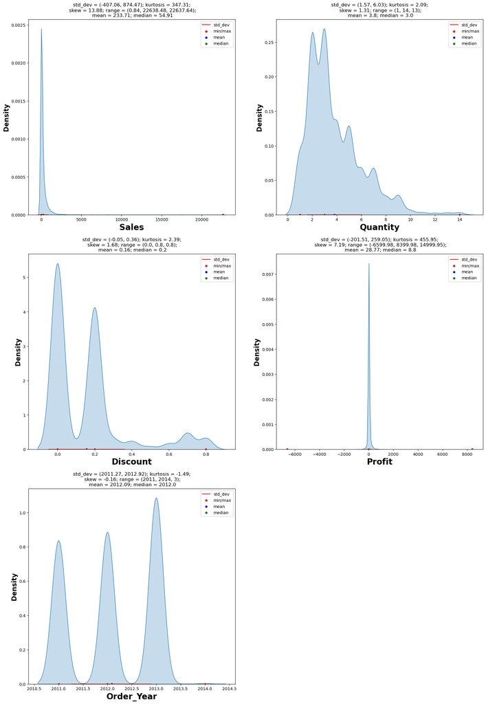

```python
UVA_numeric(train, numerical, (3,2))
```

#### Observation:

The Discount of the items range in between 0 - 80%. The most Discount for an item in the stores is 0% to 30% .

### Univariate: Categorical Features

```python
cat_features = train.select_dtypes(include = ['object']).dtypes.index
cat_features
```

```
Index(['Ship_Mode', 'Segment', 'Country', 'Category', 'Sub-Category',
       'Product_Name', 'WeekDay'],
      dtype='object')
```

```python
train['Product_Name'].value_counts()
```

```
Staple envelope                                                                          37
Staples                                                                                  31
Easy-staple paper                                                                        30
Avery Non-Stick Binders                                                                  15
KI Adjustable-Height Table                                                               12
                                                                                         ..
Xerox 1932                                                                                1
Avery 48                                                                                  1
Fellowes 8 Outlet Superior Workstation Surge Protector w/o Phone/Fax/Modem Protection     1
Eldon Antistatic Chair Mats for Low to Medium Pile Carpets                                1
Samsung Galaxy Note 2                                                                     1
Name: Product_Name, Length: 1794, dtype: int64
```

```python
def UVA_Categorical(data, cat):

    plt.figure(figsize = (10,6))
    sns.countplot(cat, data = data)
    plt.xlabel(cat,fontsize = 14, fontweight = 'bold')
    plt.ylabel('Count',fontsize = 14, fontweight = 'bold')
    plt.title('Value counts: \n{}'.format(train[cat].value_counts(normalize = True)))

# Rotating xticklabels
    if len(data[cat].value_counts()) > 7:
        X = plt.gca().xaxis
        for item in X.get_ticklabels():
            item.set_rotation(90)
    plt.show()
```

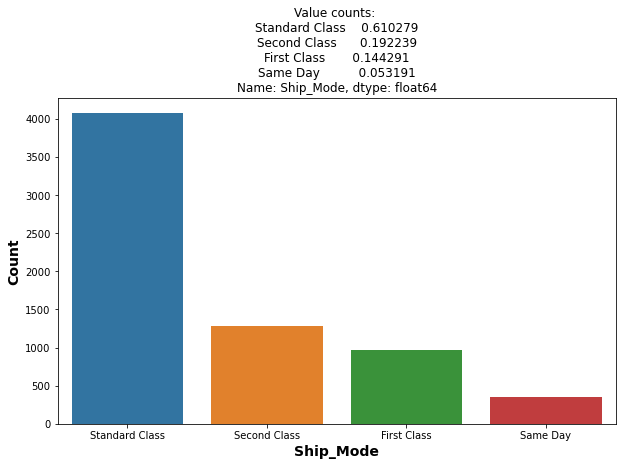

```python
UVA_Categorical(train,'Ship_Mode')
```

##### Observation:

Around 60% of the total items were delivered through Standard Class.

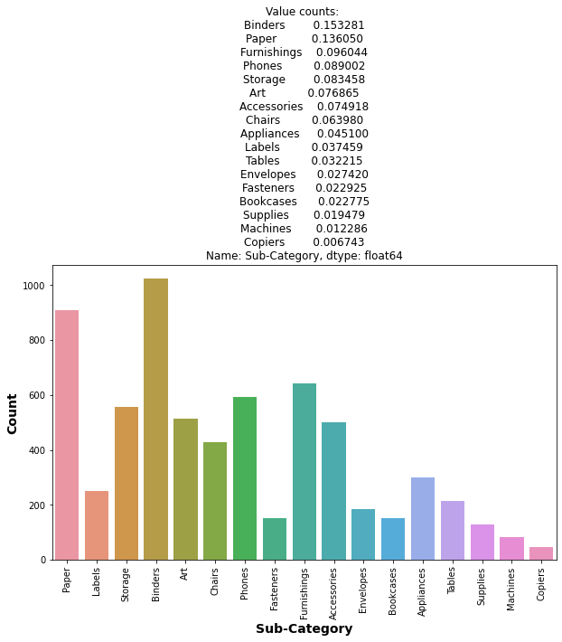

```python
UVA_Categorical(train, 'Sub-Category')
```

##### Oservations:

More than 15%(ie more than 1000 items) are Blinders.

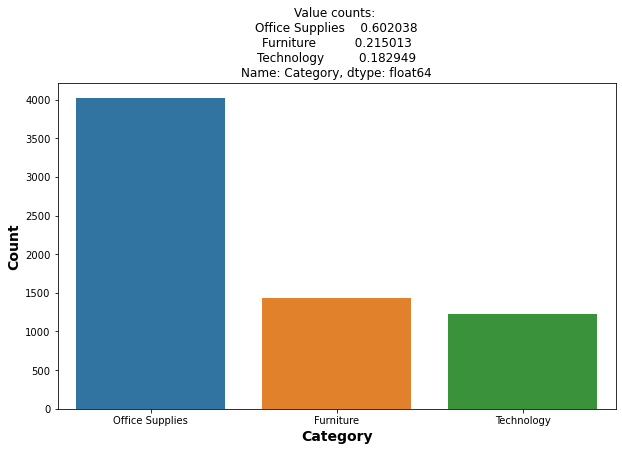

```python
UVA_Categorical(train, 'Category')
```

#### Observations:

There are total 3 Category.  
Category Office Supplies are selling more number of items than the Furnitures and Technology.

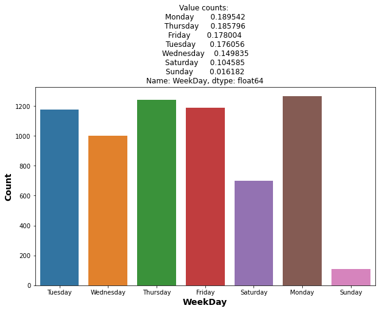

```python
UVA_Categorical(train,'WeekDay')
```

Sunday is the least ordered day compared to other weekdays

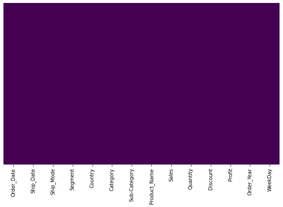

```python
plt.figure(figsize = (10,6))
sns.heatmap(train.isnull(), yticklabels=False,cbar = False,cmap ='viridis')
```

### Observation:

No, our dataset does not contain missing values.

## Bivariate Analysis

### Bivariate Analysis: Numerical-Numerical

In this section we are going to explore and analyze the data with two numerical features taking at a time.

```python
numerical = train.select_dtypes(include = ['int64','float64','Int64'])
numerical.dtypes.index
```

```
Index(['Sales', 'Quantity', 'Discount', 'Profit', 'Order_Year'], dtype='object')
```

### Correlation matrix using Pearson and Spearman correlation.

```python
numerical.corr(method = 'pearson')
```

|  | Sales | Quantity | Discount | Profit | Order_Year |
| --- | --- | --- | --- | --- | --- |
| Sales | 1.000000 | 0.204833 | -0.025839 | 0.454045 | -0.005004 |
| Quantity | 0.204833 | 1.000000 | 0.003412 | 0.072538 | -0.000507 |
| Discount | -0.025839 | 0.003412 | 1.000000 | -0.220529 | -0.007461 |
| Profit | 0.454045 | 0.072538 | -0.220529 | 1.000000 | 0.011094 |
| Order_Year | -0.005004 | -0.000507 | -0.007461 | 0.011094 | 1.000000 |

```python
numerical.corr(method='spearman')
```

|  | Sales | Quantity | Discount | Profit | Order_Year |
| --- | --- | --- | --- | --- | --- |
| Sales | 1.000000 | 0.331467 | -0.050335 | 0.519156 | 0.004097 |
| Quantity | 0.331467 | 1.000000 | 0.001682 | 0.230366 | 0.001480 |
| Discount | -0.050335 | 0.001682 | 1.000000 | -0.538736 | -0.008103 |
| Profit | 0.519156 | 0.230366 | -0.538736 | 1.000000 | 0.008114 |
| Order_Year | 0.004097 | 0.001480 | -0.008103 | 0.008114 | 1.000000 |

##### Heatmap

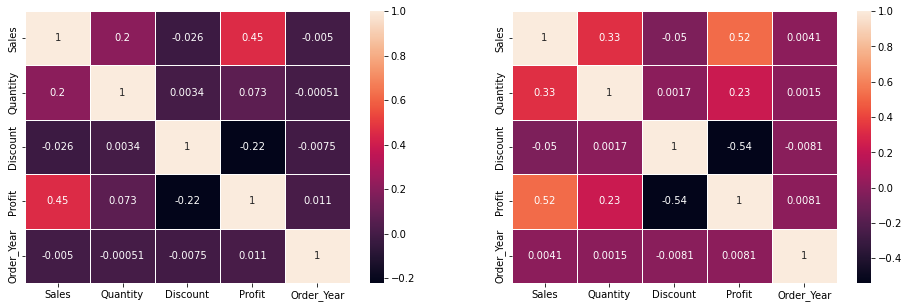

```python
plt.figure(figsize = (16,5))
plt.subplot(1,2,1)
sns.heatmap(numerical.corr(method = 'pearson'), cbar = True, annot = True,linewidths = 1)

plt.subplot(1,2,2)
sns.heatmap(numerical.corr(method = 'spearman'), cbar = True, annot = True,linewidths = 1)
```

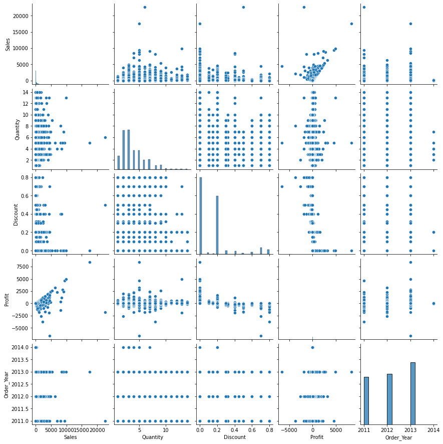

```python
sns.pairplot(numerical)
```

Profit is somewhat correlated with Discount & Sales is correlated with Profit. So Profit can be important feature for predicting Sales.

#### Bivariate Analysis: Numerical and Categorical

In this we are going to analyze our data with one categorical feature and a target variable(numerical) and also perform some hypothesis testing falling in this section.

```python
categorical = train.select_dtypes(include = 'object')
categorical.dtypes.index
```

```
Index(['Ship_Mode', 'Segment', 'Country', 'Category', 'Sub-Category',
       'Product_Name', 'WeekDay'],
      dtype='object')
```

```python
def Bivariate_cont_cat(data, cont, cat, p_value, f_value, sign_level):
    # Checking hypothesis
    if p_value < sign_level and f_value > 1:
        sign = True
    else :
        sign = False

      #table
    table = pd.pivot_table(data=data, values=cont, columns=cat, aggfunc = np.mean)


  # Visualization
    plt.figure(figsize = (20,5),dpi = 150)


    # barplot
    plt.subplot(1,3,1)
    sns.barplot(x = cat, y = cont, data = data, hue = cat)
    plt.title('anova-test P value = {} \n anova_test F value = {} \n Significant difference = {} \n{}'.format(p_value, f_value, sign, table))
    # Rotating xticklabels
    if len(data[cat].value_counts()) > 7:
        X = plt.gca().xaxis
        for item in X.get_ticklabels():
            item.set_rotation(90)

    plt.subplot(1,3,3)
    sns.boxplot(x=cat, y=cont, data=data)
    plt.title('categorical boxplot',fontsize = 14, fontweight = 'bold')

    # Rotating xticklabels
    if len(data[cat].value_counts()) > 7:
        X = plt.gca().xaxis
        for item in X.get_ticklabels():
            item.set_rotation(90)
```

```python
df_anova = train[['Sales','Category']]
grouped_anova = df_anova.groupby(['Category'])
grouped_anova.head()
from scipy import stats
f_value, p_value = stats.f_oneway(grouped_anova.get_group('Office Supplies')['Sales'],grouped_anova.get_group('Technology')['Sales'],
                                  grouped_anova.get_group('Furniture')['Sales'])
print(f_value, p_value)
```

```
182.52749927899634 6.641264326065905e-78
```

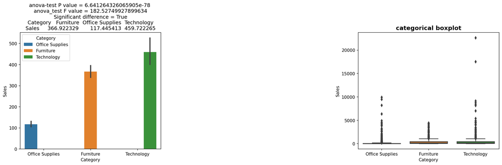

```python
Bivariate_cont_cat(train,'Sales','Category',p_value,f_value, 0.01)
```

There is a significance difference with the Category.

Outliers shown in the boxplot is due to much difference in the Item sales of different Items.

```python
train['Sub-Category'].unique()
```

```
array(['Paper', 'Labels', 'Storage', 'Binders', 'Art', 'Chairs', 'Phones',
       'Fasteners', 'Furnishings', 'Accessories', 'Envelopes',
       'Bookcases', 'Appliances', 'Tables', 'Supplies', 'Machines',
       'Copiers'], dtype=object)
```

Sales Vs Sub Category

```python
df_anova = train[['Sales','Sub-Category']]
grouped_anova = df_anova.groupby(['Sub-Category'])
grouped_anova.head()
from scipy import stats
f_value, p_value = stats.f_oneway(grouped_anova.get_group('Paper')['Sales'],grouped_anova.get_group('Labels')['Sales'],
                                  grouped_anova.get_group('Storage')['Sales'],grouped_anova.get_group('Accessories')['Sales'],
                                  grouped_anova.get_group('Binders')['Sales'],grouped_anova.get_group('Envelopes')['Sales'],
                                  grouped_anova.get_group('Art')['Sales'],grouped_anova.get_group('Bookcases')['Sales'],
                                  grouped_anova.get_group('Chairs')['Sales'],grouped_anova.get_group('Appliances')['Sales'],
                                  grouped_anova.get_group('Phones')['Sales'],grouped_anova.get_group('Tables')['Sales'],
                                  grouped_anova.get_group('Fasteners')['Sales'],grouped_anova.get_group('Supplies')['Sales'],
                                  grouped_anova.get_group('Furnishings')['Sales'],grouped_anova.get_group('Machines')['Sales'],
                                  grouped_anova.get_group('Copiers')['Sales']
                                 )
print(f_value, p_value)
```

```
98.0983792009018 7.961214131137402e-291
```

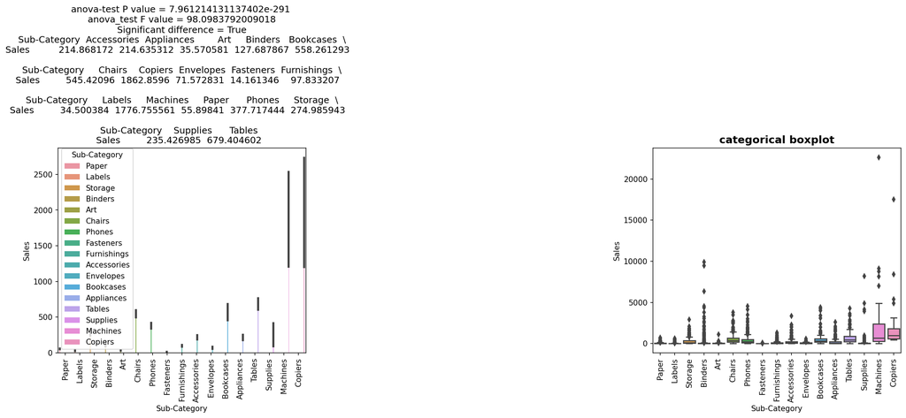

```python
Bivariate_cont_cat(train, 'Sales','Sub-Category',p_value, f_value, 0.05)
```

### Observation

There is a significance difference between sales of different Sub-Category.

Machines & Copiers products have the higher Item sales than others.

### Outlier analysis and treatment

```python
timeSeriesDF = data[['Order_Date','Sales']]
timeSeriesDF.head()
```

|  | Order_Date | Sales |
| --- | --- | --- |
| 0 | 2011-01-04 | 16.448 |
| 1 | 2011-01-05 | 11.784 |
| 2 | 2011-01-05 | 272.736 |
| 3 | 2011-01-05 | 3.540 |
| 4 | 2011-01-06 | 19.536 |

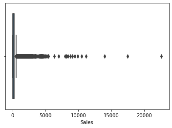

```python
sns.boxplot(timeSeriesDF['Sales'])
```

```python
q1 = np.percentile(timeSeriesDF['Sales'], 25, interpolation = 'midpoint')
q3 = np.percentile(timeSeriesDF['Sales'], 75, interpolation = 'midpoint')
iqr = q3-q1
```

```python
upper = q3 + 1.5 * iqr
lower = q1 - 1.5 * iqr
print("Upper Bound Value: ", upper)
print("Lower Bound Value: ", lower)
```

```
Upper Bound Value:  498.93
Lower Bound Value:  -271.71000000000004
```

```python
upper = timeSeriesDF['Sales'] >= (q3+1.5*iqr)
print("Upper Bound: ", upper)
print(np.where(upper))
```

```
Upper Bound:  0       False
1       False
2       False
3       False
4       False
        ...
9989    False
9990    False
9991    False
9992    False
9993    False
Name: Sales, Length: 9985, dtype: bool
(array([   7,    8,   11, ..., 9943, 9947, 9973], dtype=int64),)
```

```python
lower = timeSeriesDF['Sales'] <= (q1-1.5*iqr)
print("Lower Bound: ", lower)
print(np.where(lower))
```

```
Lower Bound:  0       False
1       False
2       False
3       False
4       False
        ...
9989    False
9990    False
9991    False
9992    False
9993    False
Name: Sales, Length: 9985, dtype: bool
(array([], dtype=int64),)
```

```python
ninp = np.percentile(timeSeriesDF['Sales'], 90)
timeSeriesDF['Sales'] = np.where(timeSeriesDF['Sales']>ninp, ninp, timeSeriesDF['Sales'])
```

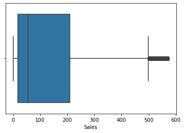

```python
sns.boxplot(timeSeriesDF['Sales'])
```

```python
data['Sales'] = np.where(data['Sales']>ninp, ninp, data['Sales'])
```

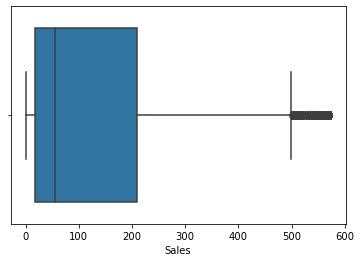

```python
sns.boxplot(data['Sales'])
```

## Feature Engineering Techniques For Time Series Data

#### We have the historical data for ‘Sales’, we have to forecast on Sales for the next 2 Years based on past data.

### Feature Engineering for Time Series : Date-Related Features

```python
data['year']=data['Order_Date'].dt.year
data['month']=data['Order_Date'].dt.month
data['day']=data['Order_Date'].dt.day

data['dayofweek_num']=data['Order_Date'].dt.dayofweek
data['dayofweek_name']=data['Order_Date'].dt.day_name()
```

### Feature Engineering for Time Series : Lag Features

```python
data['lag_1'] = data['Sales'].shift(1)
data_lag = data[['Order_Date','lag_1', 'Sales']]

data_lag.head()
```

|  | Order_Date | lag_1 | Sales |
| --- | --- | --- | --- |
| 0 | 2011-01-04 | NaN | 16.448 |
| 1 | 2011-01-05 | 16.448 | 11.784 |
| 2 | 2011-01-05 | 11.784 | 272.736 |
| 3 | 2011-01-05 | 272.736 | 3.540 |
| 4 | 2011-01-06 | 3.540 | 19.536 |

```python
data_lag['lag_1'] = data['Sales'].shift(1)
data_lag['lag_2'] = data['Sales'].shift(2)
data_lag['lag_3'] = data['Sales'].shift(3)
data_lag['lag_4'] = data['Sales'].shift(4)
data_lag['lag_5'] = data['Sales'].shift(5)
data_lag['lag_6'] = data['Sales'].shift(6)
data_lag['lag_7'] = data['Sales'].shift(7)

#data = data[['Order_Date', 'lag_1', 'lag_2', 'lag_3', 'lag_4', 'lag_5', 'lag_6', 'lag_7', 'Sales']]
data_lag.head(10)
```

|  | Order_Date | lag_1 | Sales | lag_2 | lag_3 | lag_4 | lag_5 | lag_6 | lag_7 |
| --- | --- | --- | --- | --- | --- | --- | --- | --- | --- |
| 0 | 2011-01-04 | NaN | 16.448 | NaN | NaN | NaN | NaN | NaN | NaN |
| 1 | 2011-01-05 | 16.448 | 11.784 | NaN | NaN | NaN | NaN | NaN | NaN |
| 2 | 2011-01-05 | 11.784 | 272.736 | 16.448 | NaN | NaN | NaN | NaN | NaN |
| 3 | 2011-01-05 | 272.736 | 3.540 | 11.784 | 16.448 | NaN | NaN | NaN | NaN |
| 4 | 2011-01-06 | 3.540 | 19.536 | 272.736 | 11.784 | 16.448 | NaN | NaN | NaN |
| 5 | 2011-01-07 | 19.536 | 19.440 | 3.540 | 272.736 | 11.784 | 16.448 | NaN | NaN |
| 6 | 2011-01-07 | 19.440 | 12.780 | 19.536 | 3.540 | 272.736 | 11.784 | 16.448 | NaN |
| 7 | 2011-01-07 | 12.780 | 572.580 | 19.440 | 19.536 | 3.540 | 272.736 | 11.784 | 16.448 |
| 8 | 2011-01-07 | 572.580 | 572.580 | 12.780 | 19.440 | 19.536 | 3.540 | 272.736 | 11.784 |
| 9 | 2011-01-07 | 572.580 | 5.480 | 572.580 | 12.780 | 19.440 | 19.536 | 3.540 | 272.736 |

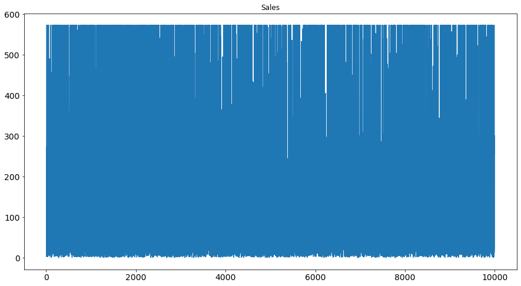

```python
fig, ax = plt.subplots(figsize=(20, 20))

data_lag.lag_7.plot(figsize=(15,8), title= 'Sales', fontsize=14)
plt.show()
```

### There is more than one way of determining the lag at which the correlation is significant. For instance, we can use the ACF (Autocorrelation Function) and PACF (Partial Autocorrelation Function) plots.¶

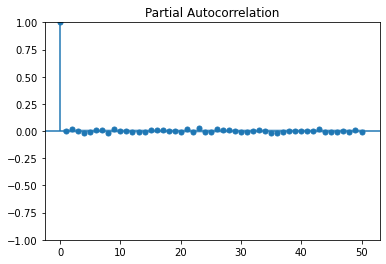

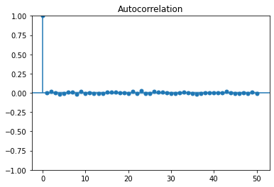

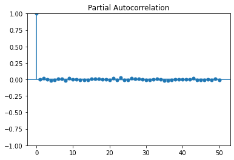

```python
from statsmodels.graphics.tsaplots import plot_acf, plot_pacf

plot_acf(data['Sales'], lags=50)
plot_pacf(data['Sales'], lags=50)
```

### Feature Engineering for Time Series : Rolling Window Feature

```python
data['rolling_mean'] = data['Sales'].rolling(window=1000).mean()
data_roll = data[['Order_Date', 'rolling_mean', 'Sales']]
data_roll.head(10)
```

|  | Order_Date | rolling_mean | Sales |
| --- | --- | --- | --- |
| 0 | 2011-01-04 | NaN | 16.448 |
| 1 | 2011-01-05 | NaN | 11.784 |
| 2 | 2011-01-05 | NaN | 272.736 |
| 3 | 2011-01-05 | NaN | 3.540 |
| 4 | 2011-01-06 | NaN | 19.536 |
| 5 | 2011-01-07 | NaN | 19.440 |
| 6 | 2011-01-07 | NaN | 12.780 |
| 7 | 2011-01-07 | NaN | 572.580 |
| 8 | 2011-01-07 | NaN | 572.580 |
| 9 | 2011-01-07 | NaN | 5.480 |

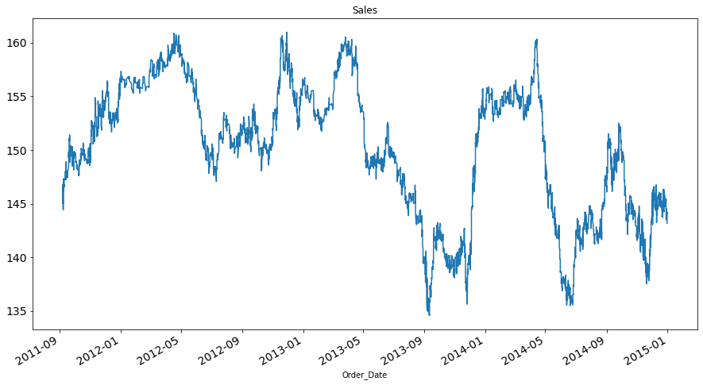

```python
data_roll.index = data_roll.Order_Date

fig, ax = plt.subplots(figsize=(20, 20))

data_roll.rolling_mean.plot(figsize=(15,8), title= 'Sales', fontsize=14)
plt.show()
```

After using rolling window method our graphs get much easier to read and understand the trends

### Expanding Window Feature

Similarly, we can consider the sum, min, max value, etc. (for the selected window) as a feature and try it out on your own machine.

Recency in an important factor in a time series. Values closer to the current date would hold more information.

Thus, we can use a weighted average, such that higher weights are given to the most recent observations. Mathematically, weighted average at time t for the past values would be:

w_avg = w1(t-1) + w2(t-2) + . . . . + w7*(t-7)

where, w1>w2>w3> . . . . >w7

```python
data['expanding_mean'] = data['Sales'].expanding(10).mean()
data_window = data[['Order_Date','Sales', 'expanding_mean']]
data_window.head()
```

|  | Order_Date | Sales | expanding_mean |
| --- | --- | --- | --- |
| 0 | 2011-01-04 | 16.448 | NaN |
| 1 | 2011-01-05 | 11.784 | NaN |
| 2 | 2011-01-05 | 272.736 | NaN |
| 3 | 2011-01-05 | 3.540 | NaN |
| 4 | 2011-01-06 | 19.536 | NaN |

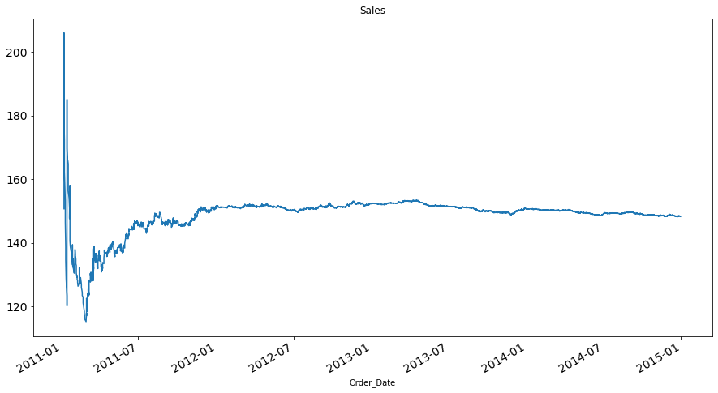

```python
data_window.index = data_window.Order_Date

fig, ax = plt.subplots(figsize=(20, 20))

data_window.expanding_mean.plot(figsize=(15,8), title= 'Sales', fontsize=14)
plt.show()
```

The above Graph dosent give much information about Sales data over time

```python
from matplotlib import rcParams
```

```python
data['year']=data['Order_Date'].dt.year
data['month']=data['Order_Date'].dt.month
data['day']=data['Order_Date'].dt.day

data['dayofweek_num']=data['Order_Date'].dt.dayofweek
data['dayofweek_name']=data['Order_Date'].dt.day_name()
df = data[['Order_Date','Sales','WeekDay','year','month','day']]
df
```

|  | Order_Date | Sales | WeekDay | year | month | day |
| --- | --- | --- | --- | --- | --- | --- |
| 0 | 2011-01-04 | 16.448 | Tuesday | 2011 | 1 | 4 |
| 1 | 2011-01-05 | 11.784 | Wednesday | 2011 | 1 | 5 |
| 2 | 2011-01-05 | 272.736 | Wednesday | 2011 | 1 | 5 |
| 3 | 2011-01-05 | 3.540 | Wednesday | 2011 | 1 | 5 |
| 4 | 2011-01-06 | 19.536 | Thursday | 2011 | 1 | 6 |
| ... | ... | ... | ... | ... | ... | ... |
| 9989 | 2014-12-31 | 90.930 | Wednesday | 2014 | 12 | 31 |
| 9990 | 2014-12-31 | 52.776 | Wednesday | 2014 | 12 | 31 |
| 9991 | 2014-12-31 | 13.904 | Wednesday | 2014 | 12 | 31 |
| 9992 | 2014-12-31 | 20.720 | Wednesday | 2014 | 12 | 31 |
| 9993 | 2014-12-31 | 3.024 | Wednesday | 2014 | 12 | 31 |

9985 rows × 6 columns

```python
df.index = df.Order_Date
```

```python
df.drop(labels=['Order_Date'],axis=1,inplace=True)
```

```python
df
```

| Order_Date | Sales | WeekDay | year | month | day |
| --- | --- | --- | --- | --- | --- |
| 2011-01-04 | 16.448 | Tuesday | 2011 | 1 | 4 |
| 2011-01-05 | 11.784 | Wednesday | 2011 | 1 | 5 |
| 2011-01-05 | 272.736 | Wednesday | 2011 | 1 | 5 |
| 2011-01-05 | 3.540 | Wednesday | 2011 | 1 | 5 |
| 2011-01-06 | 19.536 | Thursday | 2011 | 1 | 6 |
| ... | ... | ... | ... | ... | ... |
| 2014-12-31 | 90.930 | Wednesday | 2014 | 12 | 31 |
| 2014-12-31 | 52.776 | Wednesday | 2014 | 12 | 31 |
| 2014-12-31 | 13.904 | Wednesday | 2014 | 12 | 31 |
| 2014-12-31 | 20.720 | Wednesday | 2014 | 12 | 31 |
| 2014-12-31 | 3.024 | Wednesday | 2014 | 12 | 31 |

9985 rows × 5 columns

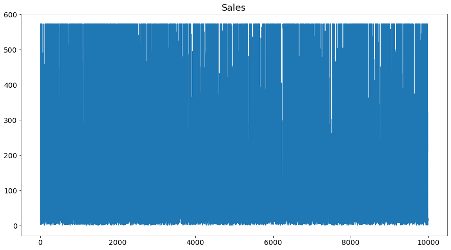

```python
rcParams["font.size"] = 15
red = "#b20710"

fig, ax = plt.subplots(figsize=(20, 20))


data.Sales.plot(figsize=(15,8), title= 'Sales', fontsize=14)
plt.show()
```

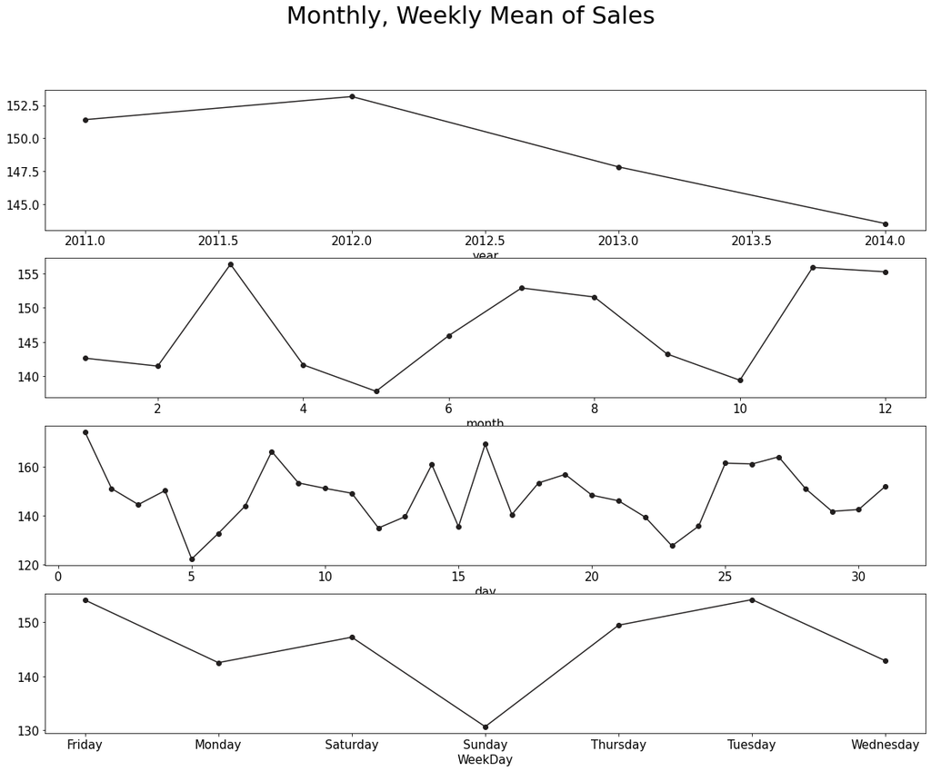

```python
feature_names = ["year", "month",'day','WeekDay']
black = "#221f1f"

fig, ax = plt.subplots(4, 1, figsize=(20, 15))
fig.suptitle("Monthly, Weekly Mean of Sales", fontsize=30)

for feature, ax in zip(feature_names, ax.flatten()):
    grouped = df.groupby(feature)["Sales"].mean()
    grouped.plot(ax=ax, color=black, marker="o")
```

```python
data.describe()
```

|  | Sales | Quantity | Discount | Profit | Order_Year | year | month | day | dayofweek_num | lag_1 | rolling_mean | expanding_mean |
| --- | --- | --- | --- | --- | --- | --- | --- | --- | --- | --- | --- | --- |
| count | 9985.000000 | 9985.000000 | 9985.000000 | 9985.000000 | 9985.000000 | 9985.000000 | 9985.000000 | 9985.000000 | 9985.000000 | 9984.000000 | 8986.000000 | 9976.000000 |
| mean | 148.243228 | 3.789685 | 0.156183 | 28.587722 | 2012.723986 | 2012.723986 | 7.816024 | 15.647972 | 2.373660 | 148.257773 | 148.844253 | 149.171109 |
| std | 186.335840 | 2.225074 | 0.206477 | 234.183523 | 1.123722 | 1.123722 | 3.285632 | 8.729690 | 1.689809 | 186.339504 | 6.304610 | 4.256650 |
| min | 0.444000 | 1.000000 | 0.000000 | -6599.978000 | 2011.000000 | 2011.000000 | 1.000000 | 1.000000 | 0.000000 | 0.444000 | 134.613811 | 115.207896 |
| 25% | 17.280000 | 2.000000 | 0.000000 | 1.731000 | 2012.000000 | 2012.000000 | 5.000000 | 8.000000 | 1.000000 | 17.295000 | 143.717855 | 148.728198 |
| 50% | 54.500000 | 3.000000 | 0.200000 | 8.671500 | 2013.000000 | 2013.000000 | 9.000000 | 16.000000 | 2.000000 | 54.514000 | 149.423574 | 149.914359 |
| 75% | 209.940000 | 5.000000 | 0.200000 | 29.364000 | 2014.000000 | 2014.000000 | 11.000000 | 23.000000 | 4.000000 | 209.940000 | 153.858918 | 151.249886 |
| max | 572.580000 | 14.000000 | 0.800000 | 8399.976000 | 2014.000000 | 2014.000000 | 12.000000 | 31.000000 | 6.000000 | 572.580000 | 160.956446 | 205.955333 |

### Have a validation strategy to check the effectiveness of new features

Almost always, we need a more robust way than just plots to assess the effectiveness of new features. For tabular data, this is often simple k-Fold cross-validation. Specific to time-series data is the TimeSeriesSplit cross-validator from Sklearn. It is designed so that in each fold, you only train a model on the past values and test it on future data points.

```python
import matplotlib.pyplot as plt

df1 = data[['Order_Date','Sales','year','month','day']]

df1
```

|  | Order_Date | Sales | year | month | day |
| --- | --- | --- | --- | --- | --- |
| 0 | 2011-01-04 | 16.448 | 2011 | 1 | 4 |
| 1 | 2011-01-05 | 11.784 | 2011 | 1 | 5 |
| 2 | 2011-01-05 | 272.736 | 2011 | 1 | 5 |
| 3 | 2011-01-05 | 3.540 | 2011 | 1 | 5 |
| 4 | 2011-01-06 | 19.536 | 2011 | 1 | 6 |
| ... | ... | ... | ... | ... | ... |
| 9989 | 2014-12-31 | 90.930 | 2014 | 12 | 31 |
| 9990 | 2014-12-31 | 52.776 | 2014 | 12 | 31 |
| 9991 | 2014-12-31 | 13.904 | 2014 | 12 | 31 |
| 9992 | 2014-12-31 | 20.720 | 2014 | 12 | 31 |
| 9993 | 2014-12-31 | 3.024 | 2014 | 12 | 31 |

9985 rows × 5 columns

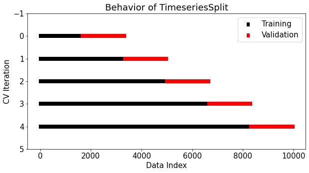

```python
from sklearn.model_selection import TimeSeriesSplit

ts_cv = TimeSeriesSplit(n_splits=5)
X, y = df1.drop("Sales", axis=1), df1[["Sales"]]

fig, ax = plt.subplots(figsize=(10, 5))
for ii, (tr, tt) in enumerate(ts_cv.split(X, y)):
    p1 = ax.scatter(tr, [ii] * len(tr), c='black', marker="_", lw=8)
    p2 = ax.scatter(tt, [ii] * len(tt), c='red', marker="_", lw=8)
    ax.set(
        title="Behavior of TimeseriesSplit",
        xlabel="Data Index",
        ylabel="CV Iteration",
        ylim=[5, -1],
    )
    ax.legend([p1, p2], ["Training", "Validation"])

plt.show();
```

##### You need to implement this local validation and establish a base performance before creating any new features. For example, train and score a baseline model like Random Forests on the initial features and set a benchmark:¶

```python
df2 = data[['Order_Date','Sales']]
df2
df2.index = df2.Order_Date
```

```python
df2
```

| Order_Date | Order_Date | Sales |
| --- | --- | --- |
| 2011-01-04 | 2011-01-04 | 16.448 |
| 2011-01-05 | 2011-01-05 | 11.784 |
| 2011-01-05 | 2011-01-05 | 272.736 |
| 2011-01-05 | 2011-01-05 | 3.540 |
| 2011-01-06 | 2011-01-06 | 19.536 |
| ... | ... | ... |
| 2014-12-31 | 2014-12-31 | 90.930 |
| 2014-12-31 | 2014-12-31 | 52.776 |
| 2014-12-31 | 2014-12-31 | 13.904 |
| 2014-12-31 | 2014-12-31 | 20.720 |
| 2014-12-31 | 2014-12-31 | 3.024 |

9985 rows × 2 columns

```python
import numpy as np
from sklearn.ensemble import RandomForestRegressor
from sklearn.model_selection import TimeSeriesSplit, cross_validate

# Init RF and CV
cv = TimeSeriesSplit(n_splits=5)
rf = RandomForestRegressor(n_estimators=1000, random_state=1121218)

#we are taking timpstamp for x and sales as target in y

X, y = df2.drop(labels=["Sales"], axis=1), df2[["Sales"]]



scores = cross_validate(
    rf, X, y, cv=cv, scoring="neg_mean_squared_log_error", return_estimator=True
)

# Base RMSLE
base_rmsle = np.sqrt(-np.mean(scores["test_score"]))
print("Base Root Meat Squared Log Error is: {:.5f}".format(base_rmsle))
```

```
Base Root Meat Squared Log Error is: 1.75830
```

```python
x = df1[["year"]]


scores = cross_validate(
    rf, x, y, cv=cv, scoring="neg_mean_squared_log_error", return_estimator=True
)
new_rmsle = np.sqrt(-np.mean(scores["test_score"]))
print("New RMSLE: {:.5f}".format(new_rmsle))
```

```
New RMSLE: 1.72398
```

Even if a slight margin improves the score, you may keep the new features because once you add many other relevant ones, the score boost can accumulate and become significant.

### Creating lagging features based on autocorrelation

Time-series data have core components like seasonality, trend, and cycles. For example, ice-cream sales usually have yearly seasonality — you can reasonably predict the next summer’s sales based on this year’s. Similarly, temperatures or air quality measurements have daily seasonality or also, yearly.

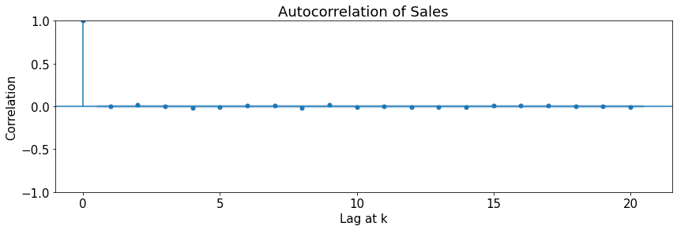

```python
from statsmodels.graphics.tsaplots import plot_acf

rcParams["figure.figsize"] = 14, 4
fig = plot_acf(data["Sales"], lags=20)

plt.title("Autocorrelation of Sales")
plt.ylabel("Correlation")
plt.xlabel("Lag at k")
fig.show();
```

### Time Series Resampling

```python
df3 = df.resample('m').mean()
```

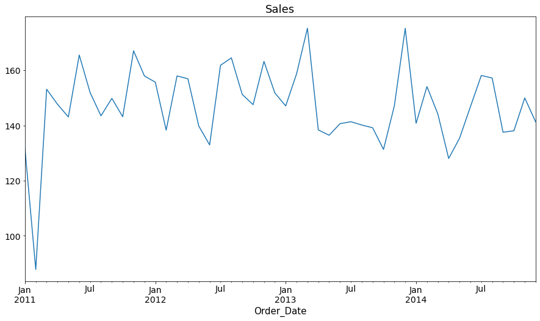

```python
fig, ax = plt.subplots(figsize=(20, 20))

df3.Sales.plot(figsize=(15,8), title= 'Sales', fontsize=14)
plt.show()
```

The above graph gives the better understanging of data so, resampling will be the better way to implement in out model